# Site Map Demo - Florida Keys

Cole Brookson

November 25, 2019

# Making a Map

## Intro

Our goal today is to make a map! Because many of my labmates work in Florida, I’ve made a demonstration map with some fake data I came up with for some sampling in the Florida Keys.

The goal of this is to build what I call a ‘Point Data’ map, wherein, I want to display some data about discrete points in space, and have the actual spatial component of the map simply be a blank background to show the relationship between these points geographically. The main message of this map is conveyed via my datapoints, and so I’ve chosen my colours etc. to reflect that.

*NOTE*: For those of you who just want the code, skip to the bottom of this document, all the code, without the descriptions will be there along with the final product

Okay, to start, load in our packages:

```r
library(mapdata)
library(maps)
library(maptools)
library(ggmap)
library(ggrepel)
library(raster)
library(ggthemes)
library(ggsn)
library(rgeos)
library(rgdal)
library(tidyverse)
library(cowplot)
```

Now for our purposes, we’re not going to use a pre-downloaded shapefile (the basis for our map), but we’re going to pull one from an online source. Looking into the `getData()` function is something I recommend if you’re curious about the actual process of getting data for something like this.

```r
#pull data from the internet
us = getData("GADM",country="USA",level=1) #pull the data on just the US

#keep only Florida
states = c('Florida')
us.states = us[us$NAME_1 %in% states,] #just keep Floida
```

For the purposes of reproducibility, I’m going to actually make the fake data here in this cell so this map will work for anyone.

```r
X = c(25.28969, 25.26436, 25.22138, 25.21373, 25.18605, 25.10439, 25.15481, #make some latitudes
      25.05991, 25.09850, 25.12508, 25.05397, 24.98026)
Y = c(-80.38285, -80.34280, -80.34901, -80.41833, -80.58600, -80.62925, #make some longitudes
      -80.47985, -80.53552, -80.91120, -80.79493, -80.68686, -80.72857)
Region = c("Barnes Sound",  "Barnes Sound",  "Barnes Sound",  "Barnes Sound",  "Florida Keys",  "Florida Keys", #make the regions
           "Florida Keys", "Florida Keys",  "Whipray Basin", "Whipray Basin", "Whipray Basin", "Whipray Basin")
FishDiv = c(45, 80, 120, 125,  60,  30, 201,  21,  78, 150, 189, 203) #create some fake biodiversity metrics (# of spp)
sites = data.frame(cbind(X, Y, Region, FishDiv)) #bind them all together
sites$Region = as.factor(sites$Region); sites$FishDiv = as.numeric(sites$FishDiv)
sites$X = as.numeric(as.character(sites$X));sites$Y = as.numeric(as.character(sites$Y))
```

NOTE*: Map making in any software, and especially R, is a completely iterative process. You will try something, it won’t work so you’ll try it again, and change one tiny thing. I will try to show that in the progression of these plots.

So let’s start with what we want this thing to look like. What I want is a zoomed-in picture of our study sites, displaying the relevant information, and a subset map showing the geographic context of our study area. I’ll also want to include all the mandatory components of any map (scalebar, north arrow, legend, axis labels). There are other things we could add but I won’t add them here.

Okay, so let’s try to get a working map going for the context of our map.

## Context Map

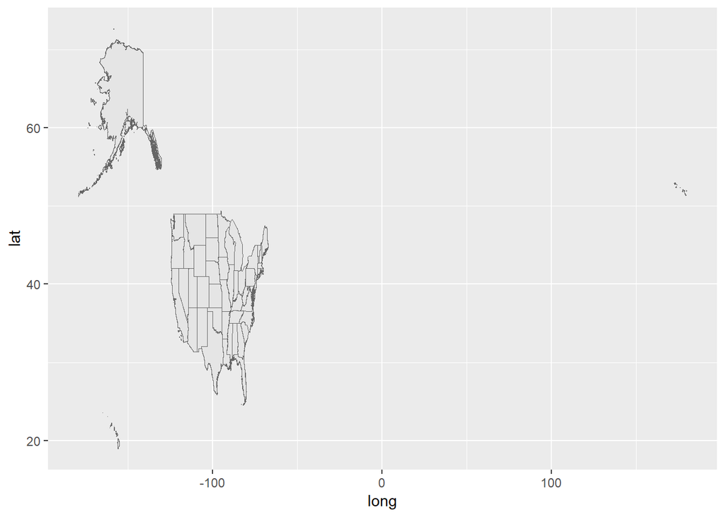

```r
ggplot()+
  geom_polygon(data = us,aes(x=long,y=lat,group=group), colour = 'grey40', #put in the data we downloade
               size = 0.01, fill = 'grey90')
```

This clearly isn’t what we want, this is every bit of the United States we could imagine including. Let’s narrow it down.

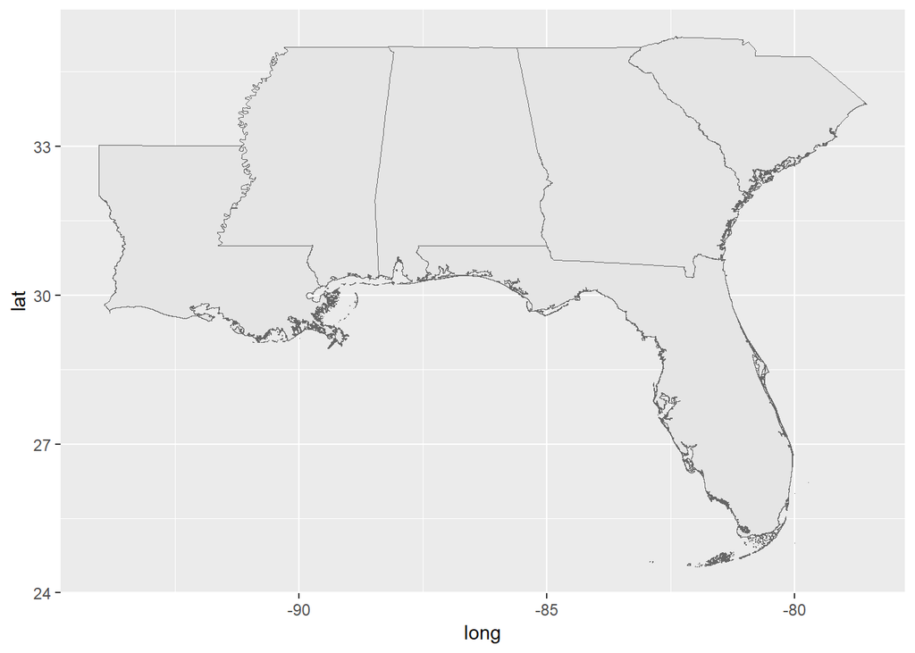

```r
other_states = c('Florida', 'Louisiana', 'South Carolina', 'Alabama', 'Georgia', 'Mississippi') #call the states we want
us = us[us$NAME_1 %in% other_states,] #keep from the whole USA data, only those states

ggplot()+
  geom_polygon(data = us,aes(x=long,y=lat,group=group), colour = 'grey40', #put in the data we downloade
               size = 0.01, fill = 'grey90')
```

Much better. Now let’s cut it down a little bit and outline Florida specifically so it’s highlighted.

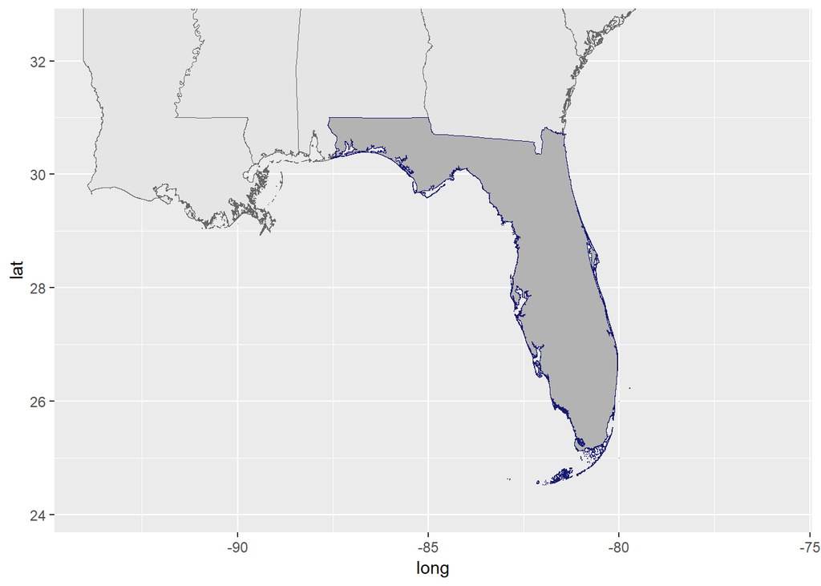

```r
ggplot()+
  geom_polygon(data = us,aes(x=long,y=lat,group=group), colour = 'grey40', #the other states
               size = 0.01, fill = 'grey90')+
  geom_polygon(data = us.states,aes(x=long,y=lat,group=group), colour = 'midnightblue', size = 0.01,
               fill = 'grey70')+ #just florida
  coord_cartesian(xlim = c(-93.9,-75.85), ylim = c(24.1,32.5)) #draw the limits of the map
```

Great. Now I want the background to look a bit different, and I don’t want any axis labels or ticks. This I will have to do through the theme. I’ll do all the things I want to do with the theme (knowing what the end product should look like) now.

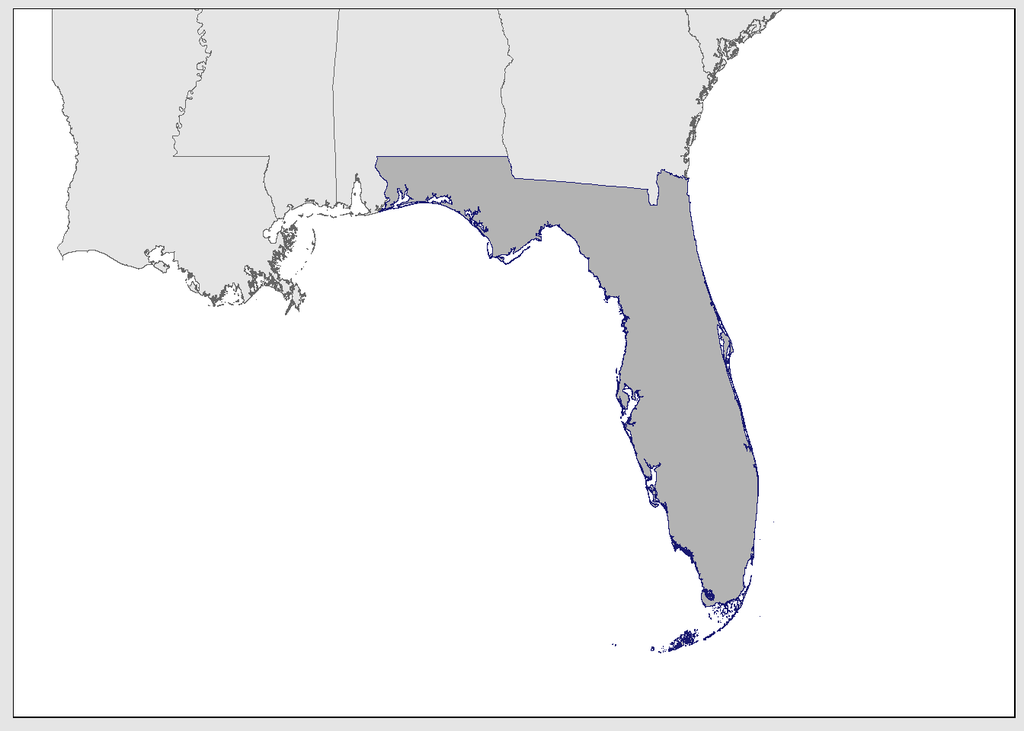

```r
fte_theme_map_small <- function(){
  color.background = 'grey90'
  color.grid.major = 'black'
  color.axis.text = 'black'
  color.axis.title = 'black'
  color.title = 'black'
  theme_bw(base_size = 9) +
    theme(panel.background = element_rect(fill= 'white',color = 'white')) +
    theme(plot.background = element_rect(fill = color.background, color = color.background)) +
    theme(panel.border = element_rect(colour = 'black')) +
    theme(panel.grid.major = element_blank()) +
    theme(panel.grid.minor = element_blank()) +
    theme(axis.ticks = element_blank()) +
    theme(plot.title = element_text(color = color.title, size = 15, vjust = 1.25)) +
    theme(axis.text.x = element_blank()) +
    theme(axis.text.y = element_blank()) +
    theme(axis.title.x = element_blank()) +
    theme(axis.title.y = element_blank()) +
    theme(plot.title = element_text(hjust = 0.5)) +
    theme(axis.line.x = element_line(color="black", size = 0.15),
          axis.line.y = element_line(color="black", size = 0.15))
}

ggplot()+
  geom_polygon(data = us,aes(x=long,y=lat,group=group), colour = 'grey40', #the other states
               size = 0.01, fill = 'grey90')+
  geom_polygon(data = us.states,aes(x=long,y=lat,group=group), colour = 'midnightblue', size = 0.01,
               fill = 'grey70')+ #just florida
  coord_cartesian(xlim = c(-93.9,-75.85), ylim = c(24.1,32.5)) +#draw the limits of the map
  fte_theme_map_small() #add the theme to the plot
```

Perfect. Now notice that the outside of the plot (the space outside the black lines) is a grey colour. This is done for a reason, I specified it in the theme, and it will become obvious why I did that later on.

Now let’s add some annotations to this to denote some points of interest.

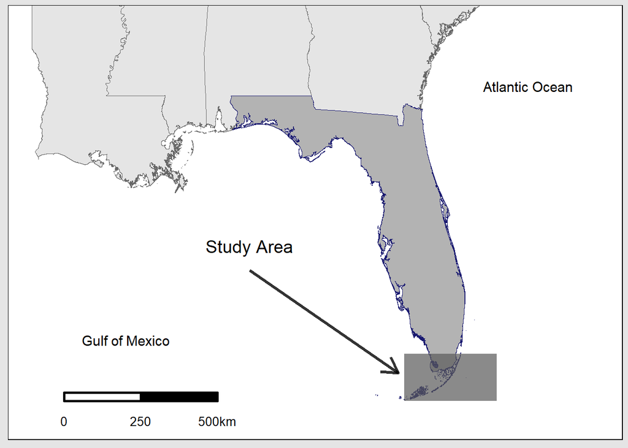

```r
continent = ggplot()+
  geom_polygon(data = us,aes(x=long,y=lat,group=group), colour = 'grey40', #the other states
               size = 0.01, fill = 'grey90')+
  geom_polygon(data = us.states,aes(x=long,y=lat,group=group), colour = 'midnightblue', size = 0.01,
               fill = 'grey70')+ #just florida
  coord_cartesian(xlim = c(-93.9,-75.85), ylim = c(24.1,32.5)) +#draw the limits of the map
  fte_theme_map_small() +#add the theme to the plot
  annotate("rect", xmin = -79, xmax = -82, ymin = 24.5, ymax = 25.5, alpha = .7)+ #add study area box
  annotate('text', x = -91, y = 25.8, label = 'Gulf of Mexico', size = 4)+
  annotate('text', x = -78, y = 31.2, label = 'Atlantic Ocean', size = 4)+
  annotate('text', x = -87, y = 27.8, label = 'Study Area', size = 5)+
  annotate('segment',x=-87, y=27.28, xend=-82.2, yend=25.1, arrow=arrow(length = unit(0.04, "npc")),
           alpha = 0.8, size=1.1, color="black")+ #this is the arrow to point towards the study area
  scalebar(x.min = -93, x.max = -85, y.min = 24.5, y.max = 25.5, dist = 250, dist_unit = 'km', st.size = 3.6,
           transform = TRUE, model = 'WGS84', location = 'bottomleft', st.dist = 0.42, height = 0.18) #this is the scalebar (a must in every map)
continent
```

Awesome. Okay, we’re looking good with this one, let’s move on to the smaller one.

## Site Map

So now I want to show the actual sites we’re working at. And I want to display my data in a useful way. First off, let’s see the region with some data points on it.

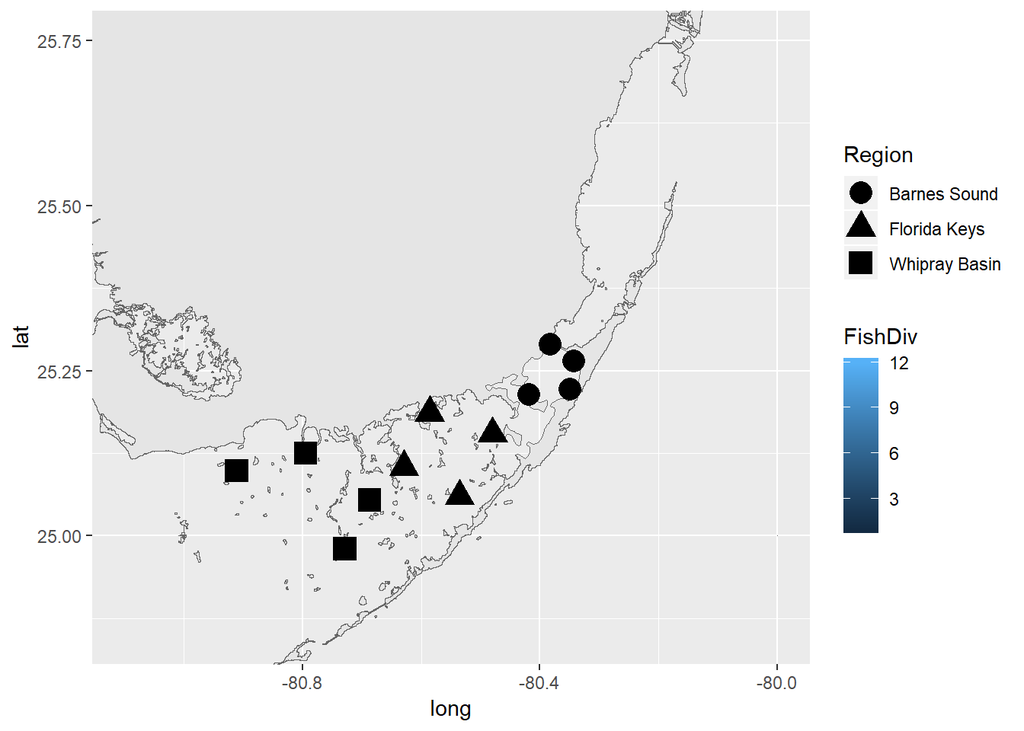

```r
ggplot()+
    geom_polygon(data = us.states,aes(x=long,y=lat,group=group), colour = 'grey40', size = 0.01,
                 fill = 'grey90')+ #just florida
  coord_cartesian(xlim = c(-80.0,-81.1), ylim = c(24.85,25.75))+ #delineate the area I want to show
  geom_point(data = sites, aes(x=Y,y=X, fill = FishDiv, shape = Region), size = 5) #delineate the points, the fish diversity data, the region of sampling, and the point size
```

There’s a lot going on in the `geom_point()` call. We see our data being called, the x and y (unintuitively) being specified, and now we want to fill the points with a colour based on how many fish are at each site and make the shape of the sites correspond to the region from the data. We also say how big we want them with the size argument.

But we see the fill colour isn’t showing up! This is a tricky one, but the reason is that R has assigned the point types automatically to certain point types that can’t be filled. So we need to change the point type to fill the inside while leaving the border black. Let’s also make the gradient our own customized one.

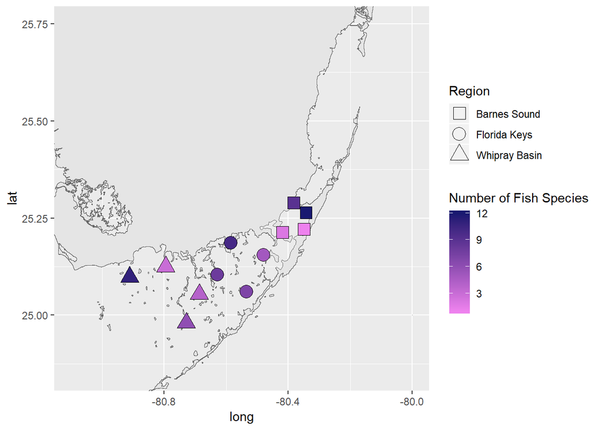

```r
ggplot()+
    geom_polygon(data = us.states,aes(x=long,y=lat,group=group), colour = 'grey40', size = 0.01,
                 fill = 'grey90')+ #just florida
  coord_cartesian(xlim = c(-80.0,-81.1), ylim = c(24.85,25.75))+ #delineate the area I want to show
    geom_point(data = sites, aes(x=Y,y=X, fill = FishDiv, shape = Region), size = 5) +#delineate the points, the fish diversity data, the region of sampling, and the point size
  scale_fill_gradient('Number of Fish Species', low = 'violet', high = 'midnightblue')+ #customize gradient
  scale_shape_manual(values = c(22,21,24))  #specify ponts that allow us to fill the middle
```

That’s looking like we want it to! Now again we don’t really want this background, and I’d prefer the legend on the plot itself. So let’s make a new theme and add it to the plot along with some finishing touches of the scalebar, the north arrow, and some proper axis labels.

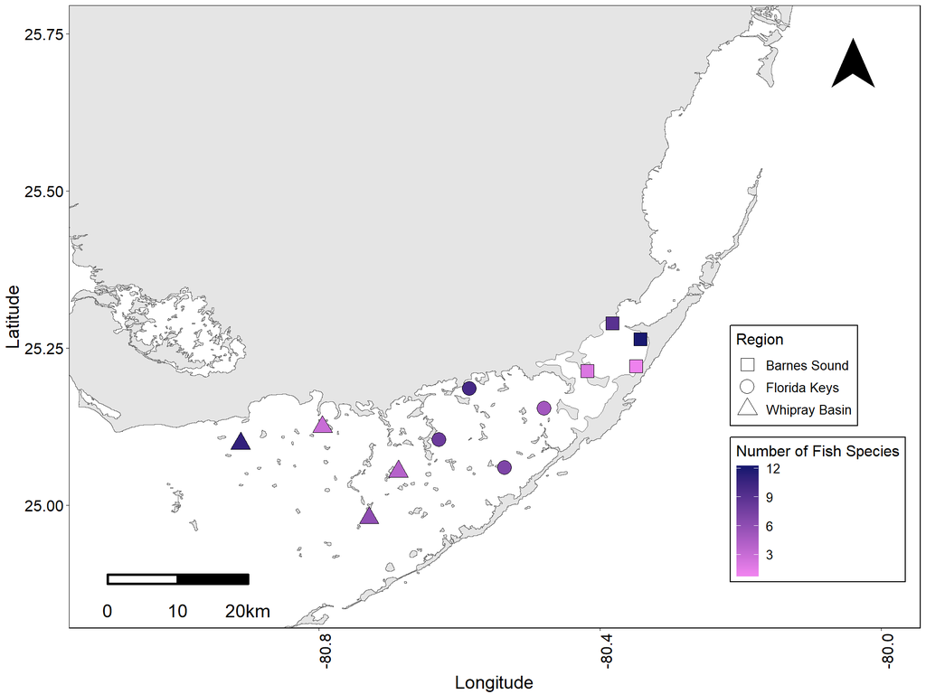

```r
#note, there's a lot going on in this theme function. Take a while to look at it and change things around to see how they change in the final map when you make alterations
fte_theme_map_sites <- function(){
  color.background = 'white'
  color.grid.major = 'black'
  color.axis.text = 'black'
  color.axis.title = 'black'
  color.title = 'black'
  theme_bw(base_size = 9) +
    theme(panel.background = element_rect(fill = 'white', color = 'white')) +
    theme(plot.background = element_rect(fill=color.background,color = color.background)) +
    theme(panel.border = element_rect(colour = 'black')) +
    theme(panel.grid.major = element_blank()) +
    theme(panel.grid.minor = element_blank()) +
    theme(axis.ticks = element_line(color="black", size = 0.15)) +
    theme(plot.title = element_text(color = color.title, size = 15, vjust = 1.25)) +
    theme(axis.text.x = element_text(size = 12, color = color.axis.text, angle = 90)) +
    theme(axis.text.y = element_text(size = 12, color = color.axis.text)) +
    theme(axis.title.x = element_text(size = 14, color = color.axis.title, vjust = 0)) +
    theme(axis.title.y = element_text(size = 14, color = color.axis.title, vjust = 1.25)) +
    theme(plot.title = element_blank()) +
    theme(axis.line.x = element_line(color="black", size = 0.15),
          axis.line.y = element_line(color="black", size = 0.15)) +
    theme(legend.position = c(0.88, 0.28),
          legend.background = element_rect(colour = 'black'),
          legend.text = element_text(size = 10),
          legend.title = element_text(size = 12))
}

sites_map = ggplot()+
    geom_polygon(data = us.states,aes(x=long,y=lat,group=group), colour = 'grey40', size = 0.01,
                 fill = 'grey90')+ #just florida
  coord_cartesian(xlim = c(-80.0,-81.1), ylim = c(24.85,25.75))+ #delineate the area I want to show
    geom_point(data = sites, aes(x=Y,y=X, fill = FishDiv, shape = Region), size = 5) +#delineate the points, the fish diversity data, the region of sampling, and the point size
  scale_fill_gradient('Number of Fish Species', low = 'violet', high = 'midnightblue')+ #customize gradient
  scale_shape_manual(values = c(22,21,24))  +#specify ponts that allow us to fill the middle
  fte_theme_map_sites() +
  labs(x = 'Longitude', y = 'Latitude')+ #add axis labels
  north(location = 'topright', scale = 0.9, symbol = 12, #add a north arrow
        x.min = -80.09, x.max = -80.0, y.min = 25.65, y.max = 25.75)+
  scalebar(x.min = -80.80, x.max = -81.1, y.min = 24.875, y.max = 24.96, dist = 10, dist_unit = 'km',
           transform = TRUE, model = 'WGS84', location = 'bottomleft', st.dist = 0.49, height = 0.18) #add a scalebar
sites_map
```

Much better. Now is to stitch our two maps together, the last step, and the simplest part

## Joined Map

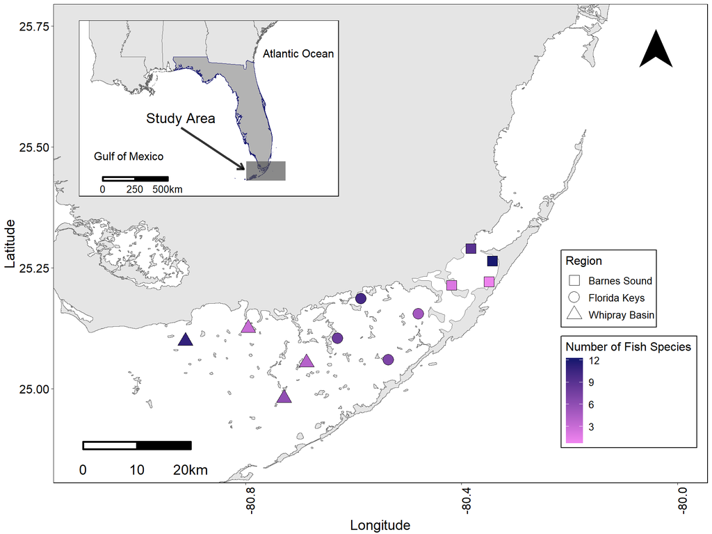

```r
ggdraw()+ #from the cowplot package
  draw_plot(sites_map) +
  draw_plot(continent, x=0.102, y=0.62, width=0.38, height=0.35)
```

And we’re done, we have a map with all the components we wanted.

## Uncommented Final Code

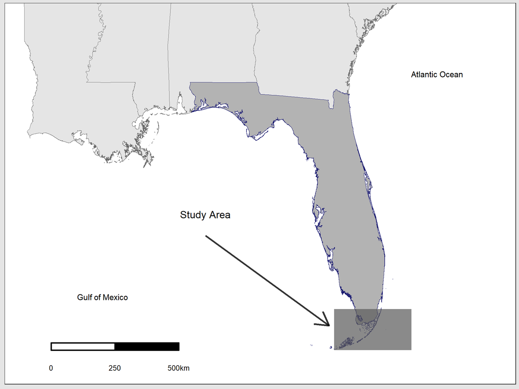

```r
#make the themes
fte_theme_map_small <- function(){
  color.background = 'grey90'
  color.grid.major = 'black'
  color.axis.text = 'black'
  color.axis.title = 'black'
  color.title = 'black'
  theme_bw(base_size = 9) +
    theme(panel.background = element_rect(fill= 'white',color = 'white')) +
    theme(plot.background = element_rect(fill = color.background, color = color.background)) +
    theme(panel.border = element_rect(colour = 'black')) +
    theme(panel.grid.major = element_blank()) +
    theme(panel.grid.minor = element_blank()) +
    theme(axis.ticks = element_blank()) +
    theme(plot.title = element_text(color = color.title, size = 15, vjust = 1.25)) +
    theme(axis.text.x = element_blank()) +
    theme(axis.text.y = element_blank()) +
    theme(axis.title.x = element_blank()) +
    theme(axis.title.y = element_blank()) +
    theme(plot.title = element_text(hjust = 0.5)) +
    theme(axis.line.x = element_line(color="black", size = 0.15),
          axis.line.y = element_line(color="black", size = 0.15))
}
fte_theme_map_sites <- function(){
  color.background = 'white'
  color.grid.major = 'black'
  color.axis.text = 'black'
  color.axis.title = 'black'
  color.title = 'black'
  theme_bw(base_size = 9) +
    theme(panel.background = element_rect(fill = 'white', color = 'white')) +
    theme(plot.background = element_rect(fill=color.background,color = color.background)) +
    theme(panel.border = element_rect(colour = 'black')) +
    theme(panel.grid.major = element_blank()) +
    theme(panel.grid.minor = element_blank()) +
    theme(axis.ticks = element_line(color="black", size = 0.15)) +
    theme(plot.title = element_text(color = color.title, size = 15, vjust = 1.25)) +
    theme(axis.text.x = element_text(size = 12, color = color.axis.text, angle = 90)) +
    theme(axis.text.y = element_text(size = 12, color = color.axis.text)) +
    theme(axis.title.x = element_text(size = 14, color = color.axis.title, vjust = 0)) +
    theme(axis.title.y = element_text(size = 14, color = color.axis.title, vjust = 1.25)) +
    theme(plot.title = element_blank()) +
    theme(axis.line.x = element_line(color="black", size = 0.15),
          axis.line.y = element_line(color="black", size = 0.15)) +
    theme(legend.position = c(0.88, 0.28),
          legend.background = element_rect(colour = 'black'),
          legend.text = element_text(size = 10),
          legend.title = element_text(size = 12))
}

#make larger map to put study area in context
continent = ggplot()+
  geom_polygon(data = us,aes(x=long,y=lat,group=group), colour = 'grey40',
               size = 0.01, fill = 'grey90')+
  geom_polygon(data = us.states,aes(x=long,y=lat,group=group), colour = 'midnightblue', size = 0.01,
               fill = 'grey70')+
  coord_cartesian(xlim = c(-93.9,-75.85), ylim = c(24.1,32.5)) +
  fte_theme_map_small() +
  annotate("rect", xmin = -79, xmax = -82, ymin = 24.5, ymax = 25.5, alpha = .7)+
  annotate('text', x = -91, y = 25.8, label = 'Gulf of Mexico', size = 4)+
  annotate('text', x = -78, y = 31.2, label = 'Atlantic Ocean', size = 4)+
  annotate('text', x = -87, y = 27.8, label = 'Study Area', size = 5)+
  annotate('segment',x=-87, y=27.28, xend=-82.2, yend=25.1, arrow=arrow(length = unit(0.04, "npc")),
           alpha = 0.8, size=1.1, color="black")+
  scalebar(x.min = -93, x.max = -85, y.min = 24.5, y.max = 25.5, dist = 250, dist_unit = 'km', st.size = 3.6,
           transform = TRUE, model = 'WGS84', location = 'bottomleft', st.dist = 0.42, height = 0.18)
continent
```

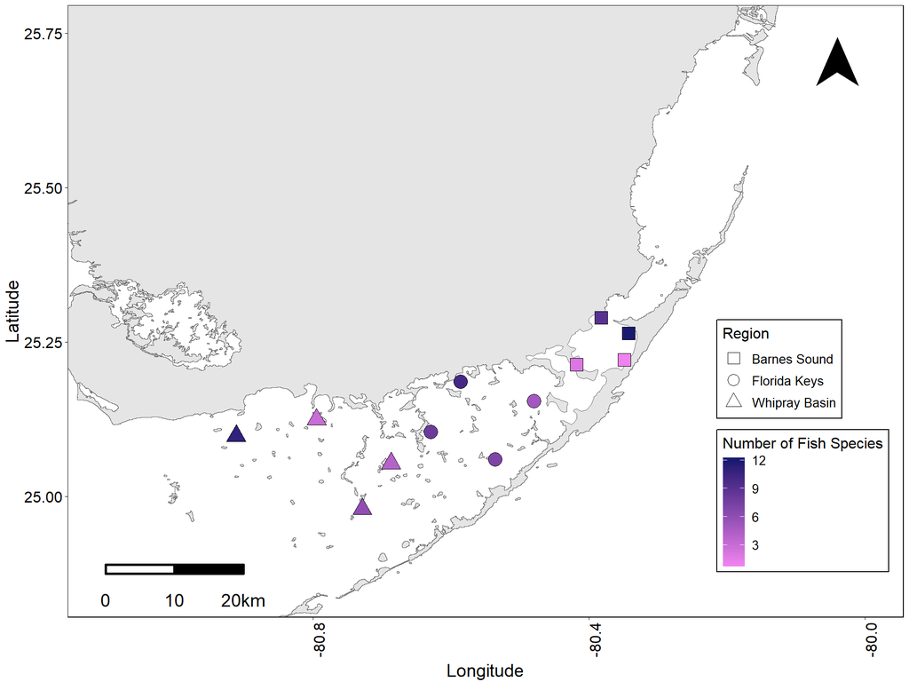

```r
#make the site-level map
sites_map = ggplot()+
    geom_polygon(data = us.states,aes(x=long,y=lat,group=group), colour = 'grey40', size = 0.01,
                 fill = 'grey90')+
  coord_cartesian(xlim = c(-80.0,-81.1), ylim = c(24.85,25.75)) +
  geom_point(data = sites, aes(x=Y,y=X, fill = FishDiv, shape = Region), size = 5)+
  scale_fill_gradient('Number of Fish Species', low = 'violet', high = 'midnightblue')+
  scale_shape_manual(values = c(22,21,24)) +
  guides(shape = guide_legend(override.aes = list(size = 4, shape = c(0,1,2)))) +
  fte_theme_map_sites() +
  labs(x = 'Longitude', y = 'Latitude')+
  north(location = 'topright', scale = 0.9, symbol = 12,
        x.min = -80.09, x.max = -80.0, y.min = 25.65, y.max = 25.75)+
  scalebar(x.min = -80.80, x.max = -81.1, y.min = 24.875, y.max = 24.96, dist = 10, dist_unit = 'km',
           transform = TRUE, model = 'WGS84', location = 'bottomleft', st.dist = 0.49, height = 0.18)
sites_map
```

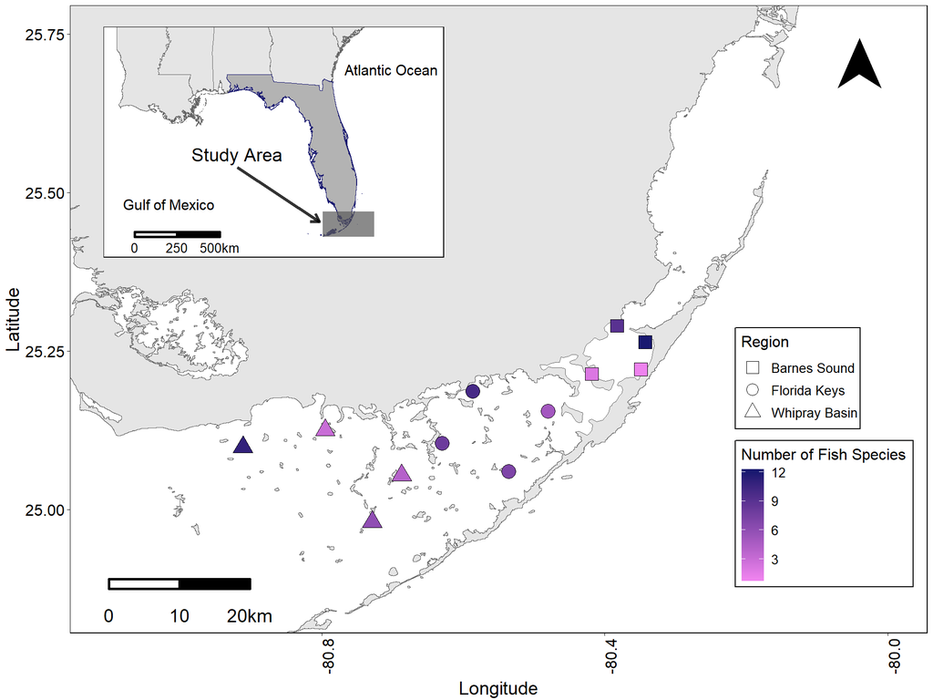

```r
#make the one plot inset with the other
insetmap = ggdraw()+
  draw_plot(sites_map) +
  draw_plot(continent, x=0.102, y=0.62, width=0.38, height=0.35)
insetmap
```